# Sprawozdanie

**Z projektu - interpolacja litofacji wspomagana sztuczną inteligencją**  
*Autor: Ewa Szewczyk, nr indeksu: 406923*

Celem projektu jest użycie metod sztucznej inteligencji do poprawnej klasyfikacji litofacji na podstawie danych 3D.

### Ustawienia notatnika

```python
from segysak.segy import (
    get_segy_texthead,
    segy_header_scan,
    segy_loader,
)

import numpy as np

import matplotlib.pyplot as plt
import seaborn as sns
from matplotlib import cm

pal = cm.get_cmap("viridis", 5)

from sklearn.cluster import KMeans
from sklearn.metrics import silhouette_score
import skfuzzy as fuzz
```

## 1. Wgranie danych przy użyciu biblioteki SEGYSAK

### 1.1. Wczytanie nagłówku tekstowego

```python
ebcdic = get_segy_texthead("TNE01_Full")

print(type(ebcdic))
ebcdic
```

```
<class 'segysak._richstr.rich_texthead'>
```

Text Header

C 1 SEGY OUTPUT FROM Petrel 2019.4 Wednesday, October 21 2020 14:19:53 C 2 Name: TNE01_FULL ÝRealized¨ 1 Type: 3D seismic C 3 C 4 First inline: 362 Last inline: 1540 C 5 First xline: 908 Last xline: 3880 C 6 CRS: ST_ED50_UTM31N_P23031_T1133 ÝStatoil,2100005¨ C 7 X min: 531854.62 max: 563388.48 delta: 31533.86 C 8 Y min: 6731674.15 max: 6771202.25 delta: 39528.10 C 9 Time min: -4000.00 max: 4.00 delta: 4004.00 C10 Lat min: 60.42'51.1341"N max: 61.04'22.1371"N delta: 0.21'31.0031" C11 Long min: 3.35'1.5768"E max: 4.10'28.3122"E delta: 0.35'26.7354" C12 Trace min: -3998.00 max: 2.00 delta: 4000.00 C13 Seismic (template) min: -304.74 max: 302.36 delta: 607.11 C14 Amplitude (data) min: -304.74 max: 302.36 delta: 607.11 C15 Trace sample format: IEEE floating point C16 Coordinate scale factor: 10.00000 C17 C18 Binary header locations: C19 Sample interval : bytes 17-18 C20 Number of samples per trace : bytes 21-22 C21 Trace date format : bytes 25-26 C22 C23 Trace header locations: C24 Inline number : bytes 5-8 C25 Xline number : bytes 21-24 C26 Coordinate scale factor : bytes 71-72 C27 X coordinate : bytes 73-76 C28 Y coordinate : bytes 77-80 C29 Trace start time/depth : bytes 109-110 C30 Number of samples per trace : bytes 115-116 C31 Sample interval : bytes 117-118 C32 C33 C34 C35 C36 C37 C38 C39 C40 END EBCDIC

### 1.2 Sprawdzenie lokalizacji typowych bytów

```python
scan = segy_header_scan("TNE01_Full")

scan[scan["std"] > 0]
```

|  | byte_loc | count | mean | std | min | 25% | 50% | 75% | max |
| --- | --- | --- | --- | --- | --- | --- | --- | --- | --- |
| TRACE_SEQUENCE_LINE | 1 | 1000.0 | 5.005000e+02 | 288.819436 | 1.0 | 250.75 | 500.5 | 750.25 | 1000.0 |
| TraceNumber | 13 | 1000.0 | 5.005000e+02 | 288.819436 | 1.0 | 250.75 | 500.5 | 750.25 | 1000.0 |
| CDP | 21 | 1000.0 | 1.907000e+03 | 577.638872 | 908.0 | 1407.50 | 1907.0 | 2406.50 | 2906.0 |
| SourceX | 73 | 1000.0 | 5.570523e+06 | 36537.740701 | 5507333.0 | 5538928.25 | 5570523.5 | 5602118.50 | 5633714.0 |
| SourceY | 77 | 1000.0 | 6.749913e+07 | 62278.028634 | 67391426.0 | 67445279.25 | 67499133.0 | 67552986.00 | 67606840.0 |
| CDP_X | 181 | 1000.0 | 5.570523e+06 | 36537.740701 | 5507333.0 | 5538928.25 | 5570523.5 | 5602118.50 | 5633714.0 |
| CDP_Y | 185 | 1000.0 | 6.749913e+07 | 62278.028634 | 67391426.0 | 67445279.25 | 67499133.0 | 67552986.00 | 67606840.0 |
| CROSSLINE_3D | 193 | 1000.0 | 1.907000e+03 | 577.638872 | 908.0 | 1407.50 | 1907.0 | 2406.50 | 2906.0 |

Lokalizacja bytów w używanym pliku (plik EBCDIC) jest inna niż te, które są domyślne (powyżej). Należy je poprawnie ustawić przy wczytywaniu.

### 1.3 Wczytanie pliku

```python
V3D = segy_loader("TNE01_Full", iline=5, xline=21, cdpx=73, cdpy=77, vert_domain="TWT")

V3D
```

```
Loading as 3D
Fast direction is TRACE_SEQUENCE_FILE
```

```
<xarray.Dataset>
Dimensions:  (iline: 590, xline: 1487, twt: 1001)
Coordinates:
  * iline    (iline) uint16 362 364 366 368 370 372 ... 1532 1534 1536 1538 1540
  * xline    (xline) uint16 908 910 912 914 916 918 ... 3872 3874 3876 3878 3880
  * twt      (twt) float64 -2.0 2.0 6.0 10.0 ... 3.99e+03 3.994e+03 3.998e+03
    cdp_x    (iline, xline) float32 5.634e+05 5.634e+05 ... 5.319e+05 5.319e+05
    cdp_y    (iline, xline) float32 6.739e+06 6.739e+06 ... 6.764e+06 6.764e+06
Data variables:
    data     (iline, xline, twt) float32 0.0 0.0 0.0 0.0 0.0 ... 0.0 0.0 0.0 0.0
Attributes: (12/13)
    ns:                  None
    sample_rate:         4.0
    text:                C 1 SEGY OUTPUT FROM Petrel 2019.4 Wednesday, Octobe...
    measurement_system:  m
    d3_domain:           None
    epsg:                None
    ...                  ...
    corner_points_xy:    None
    source_file:         TNE01_Full
    srd:                 None
    datatype:            None
    percentiles:         [-6.62317201331616e-68, -4.41544786148683e-68, -2.20...
    coord_scalar:        -10.0
```

### 1.4 Wizualizacja środkowego inline, xline oraz time slice

```python
# Sprawdzanie środkowych wartości

print("iline:", V3D.data.iline.median().values)
print("xline:", V3D.data.xline.median().values)
print("twt:", V3D.data.twt.median().values)
```

```
iline: 951.0
xline: 2394.0
twt: 1998.0
```

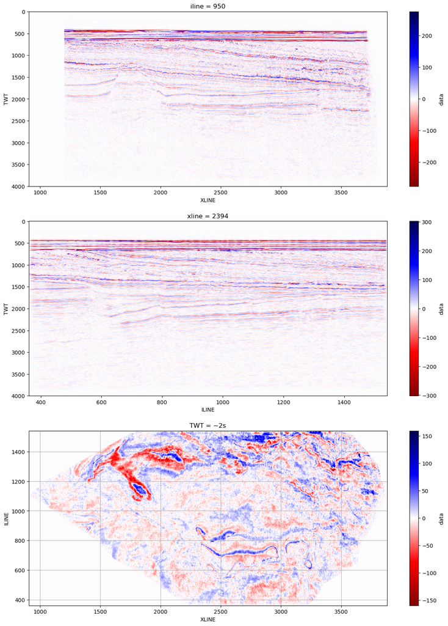

```python
fig, ax = plt.subplots(ncols=1, nrows=3, figsize=(15, 20))
iline_sel = 950  # dla 951 nie ma
V3D.data.transpose("twt", "iline", "xline", transpose_coords=True).sel(
    iline=iline_sel
).plot(yincrease=False, cmap="seismic_r", ax=ax[0])
plt.grid("gray")
ax[0].set(ylabel="TWT", xlabel="XLINE")

xline_sel = 2394
V3D.data.transpose("twt", "iline", "xline", transpose_coords=True).sel(
    xline=xline_sel
).plot(yincrease=False, cmap="seismic_r", ax=ax[1])
plt.grid("gray")
ax[1].set(ylabel="TWT", xlabel="ILINE")

twt_value = 1998
data_at_twt = V3D.data.sel(twt=twt_value, method="nearest")
data_at_twt.transpose("iline", "xline").plot(ax=ax[2], cmap="seismic_r")
plt.grid("gray")
ax[2].set(ylabel="ILINE", xlabel="XLINE", title="TWT = ~2s")

plt.show()
```

### 1.5 Ograniczenie zakresów

```python
iline_range = (500, 1400)
xline_range = (2000, 3000)
twt_range = (1900, 2100)

smaller_cube = V3D.sel(
    iline=slice(iline_range[0], iline_range[1]),
    xline=slice(xline_range[0], xline_range[1]),
    twt=slice(twt_range[0], twt_range[1]),
)

smaller_cube
```

```
<xarray.Dataset>
Dimensions:  (iline: 451, xline: 501, twt: 50)
Coordinates:
  * iline    (iline) uint16 500 502 504 506 508 510 ... 1392 1394 1396 1398 1400
  * xline    (xline) uint16 2000 2002 2004 2006 2008 ... 2994 2996 2998 3000
  * twt      (twt) float64 1.902e+03 1.906e+03 1.91e+03 ... 2.094e+03 2.098e+03
    cdp_x    (iline, xline) float32 5.55e+05 5.55e+05 ... 5.39e+05 5.389e+05
    cdp_y    (iline, xline) float32 6.75e+06 6.75e+06 ... 6.755e+06 6.755e+06
Data variables:
    data     (iline, xline, twt) float32 -4.762 -2.381 0.0 ... 4.762 -14.28
Attributes: (12/13)
    ns:                  None
    sample_rate:         4.0
    text:                C 1 SEGY OUTPUT FROM Petrel 2019.4 Wednesday, Octobe...
    measurement_system:  m
    d3_domain:           None
    epsg:                None
    ...                  ...
    corner_points_xy:    None
    source_file:         TNE01_Full
    srd:                 None
    datatype:            None
    percentiles:         [-6.62317201331616e-68, -4.41544786148683e-68, -2.20...
    coord_scalar:        -10.0
```

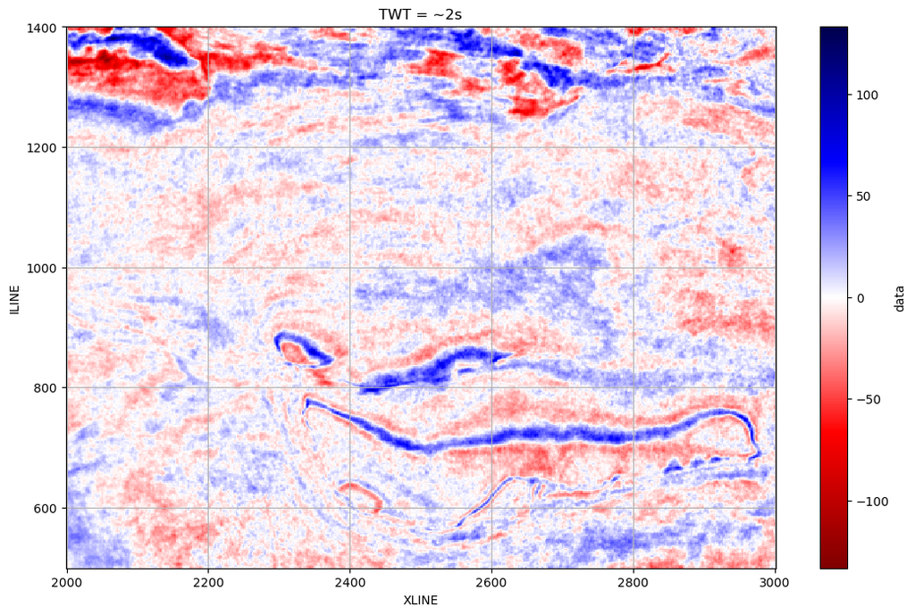

```python
fig, ax = plt.subplots(1, 1, figsize=(13, 8))

twt_value = 1998
data_at_twt = smaller_cube.data.sel(twt=twt_value, method="nearest")
data_at_twt.transpose("iline", "xline").plot(ax=ax, cmap="seismic_r")
plt.grid("gray")
ax.set(ylabel="ILINE", xlabel="XLINE", title="TWT = ~2s")

plt.show()
```

## 2. Konwersja XArray do Numpy

```python
np_cube = smaller_cube["data"].values

print(np_cube.shape)
np_cube
```

```
(451, 501, 50)
```

[output not shown]

[output cut: 30 more lines]

[output not shown]

## 3. Klasteryzacja przy użyciu algorytmu k-means oraz fuzzy c-means

Oba algorytmy k-means oraz fuzzy c-means służą do klasteryzacji, czyli podziału danych na wyróżniające się wspólnymi cechami grupy, ale różnią się w sposobie przypisywania punktów do klastrów. Zasadniczą różnicą jest wykorzystanie logiki klasycznej i teorii zbiorów w przypadku algorytmu k-means (obiekt należy lub nienależy do zbioru) oraz logiki trójwartościowej i teorii zbiorów rozmytych w przypadku fuzzy c-means.

### 3.1 Klasteryzacja na slice

Stworzono klasteryzację dla 3 slice'ów - 1, 225 i 400.

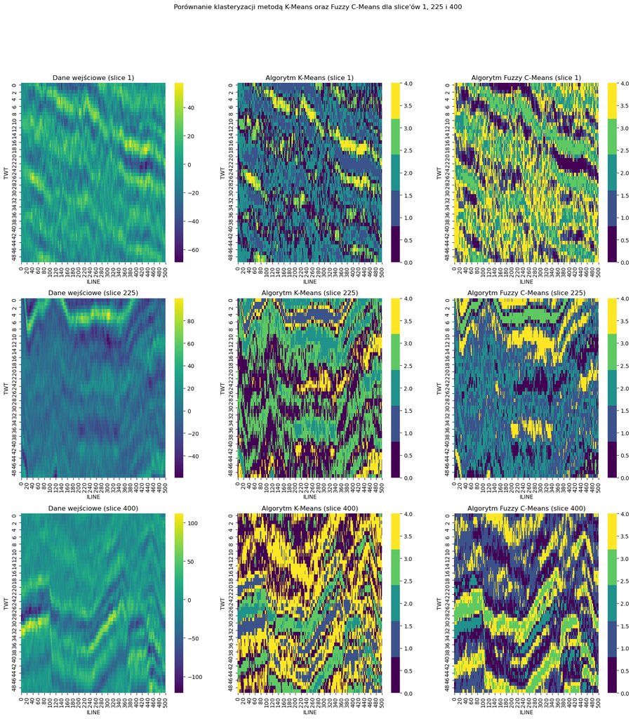

```python
# Wyciągnięcie slice'ów
slice_1 = np_cube[1, :, :]
slice_225 = np_cube[225, :, :]
slice_400 = np_cube[400, :, :]


# Reshape
slice_1_reshaped = slice_1.reshape(-1, 1)
slice_225_reshaped = slice_225.reshape(-1, 1)
slice_400_reshaped = slice_400.reshape(-1, 1)

# Kmeans
kmeans = KMeans(n_clusters=5, random_state=44, n_init="auto").fit(slice_1_reshaped)
clustered_slice_1 = kmeans.labels_.reshape(slice_1.shape)

kmeans = KMeans(n_clusters=5, random_state=44, n_init="auto").fit(slice_225_reshaped)
clustered_slice_225 = kmeans.labels_.reshape(slice_225.shape)

kmeans = KMeans(n_clusters=5, random_state=44, n_init="auto").fit(slice_400_reshaped)
clustered_slice_400 = kmeans.labels_.reshape(slice_400.shape)

# Fuzzy
cntr, u, u0, d, jm, p, fpc = fuzz.cluster.cmeans(
    slice_1_reshaped.T, c=5, m=2, error=0.005, maxiter=1000, init=None, seed=44
)
clustered_slice_fuzzy_1 = np.argmax(u, axis=0).reshape(slice_1.shape)

cntr, u, u0, d, jm, p, fpc = fuzz.cluster.cmeans(
    slice_225_reshaped.T, c=5, m=2, error=0.005, maxiter=1000, init=None, seed=44
)
clustered_slice_fuzzy_225 = np.argmax(u, axis=0).reshape(slice_225.shape)

cntr, u, u0, d, jm, p, fpc = fuzz.cluster.cmeans(
    slice_400_reshaped.T, c=5, m=2, error=0.005, maxiter=1000, init=None, seed=44
)
clustered_slice_fuzzy_400 = np.argmax(u, axis=0).reshape(slice_400.shape)

# Wykresy
fig, axes = plt.subplots(3, 3, figsize=(20, 20))
sns.heatmap(slice_1.T, ax=axes[0, 0], cmap="viridis")
sns.heatmap(clustered_slice_1.T, ax=axes[0, 1], cmap=pal)
sns.heatmap(clustered_slice_fuzzy_1.T, ax=axes[0, 2], cmap=pal)

sns.heatmap(slice_225.T, ax=axes[1, 0], cmap="viridis")
sns.heatmap(clustered_slice_225.T, ax=axes[1, 1], cmap=pal)
sns.heatmap(clustered_slice_fuzzy_225.T, ax=axes[1, 2], cmap=pal)

sns.heatmap(slice_400.T, ax=axes[2, 0], cmap="viridis")
sns.heatmap(clustered_slice_400.T, ax=axes[2, 1], cmap=pal)
sns.heatmap(clustered_slice_fuzzy_400.T, ax=axes[2, 2], cmap=pal)

axes[0, 0].set(title="Dane wejściowe (slice 1)", ylabel="TWT", xlabel="ILINE")
axes[0, 1].set(title="Algorytm K-Means (slice 1)", ylabel="TWT", xlabel="ILINE")
axes[0, 2].set(title="Algorytm Fuzzy C-Means (slice 1)", ylabel="TWT", xlabel="ILINE")

axes[1, 0].set(title="Dane wejściowe (slice 225)", ylabel="TWT", xlabel="ILINE")
axes[1, 1].set(title="Algorytm K-Means (slice 225)", ylabel="TWT", xlabel="ILINE")
axes[1, 2].set(title="Algorytm Fuzzy C-Means (slice 225)", ylabel="TWT", xlabel="ILINE")

axes[2, 0].set(title="Dane wejściowe (slice 400)", ylabel="TWT", xlabel="ILINE")
axes[2, 1].set(title="Algorytm K-Means (slice 400)", ylabel="TWT", xlabel="ILINE")
axes[2, 2].set(title="Algorytm Fuzzy C-Means (slice 400)", ylabel="TWT", xlabel="ILINE")


fig.suptitle(
    "Porównanie klasteryzacji metodą K-Means oraz Fuzzy C-Means dla slice'ów 1, 225 i 400"
)
plt.show()
```

Podstawową zaletą klasteryzacji jest wyraźniejsze rozróżnienie poszczególnych warstw. Wzory które wyłaniają się po klasteryzacji pasują kształtem/wzorcem do danych wejściowych, ale znacznie wyraźniej pokazują różnice między nimi. Wyniki klasteryzacji oboma metodami dają podobne wyniki, przy czym w zależności od slice'u czasami wyniki K-Means, a czasami wyniki Fuzzy C-Means lepiej "gładziej" pokazują różne warstwy. Pomimo braku potrzebnej wiedzy dziedzinowej z całą pewnością można stwierdzić, że taka klasyfikacja ma sens, a jej rezultaty potrafią pokazać odrębne wzorce.

### 3.2 Klasteryzacja 3D

```python
## K-Means
np_cube_reshaped = np_cube.reshape(-1, 1)
kmeans_all = KMeans(n_clusters=5, random_state=0, n_init="auto").fit(np_cube_reshaped)
clustered_cube = kmeans_all.labels_.reshape(np_cube.shape)

## FCM
cntr_all, u_all, u0_all, d_all, jm_all, p_all, fpc_all = fuzz.cluster.cmeans(
    np_cube_reshaped.T, c=5, m=2, error=0.005, maxiter=1000, init=None
)
clustered_cube_fuzzy = np.argmax(u_all, axis=0).reshape(np_cube.shape)
```

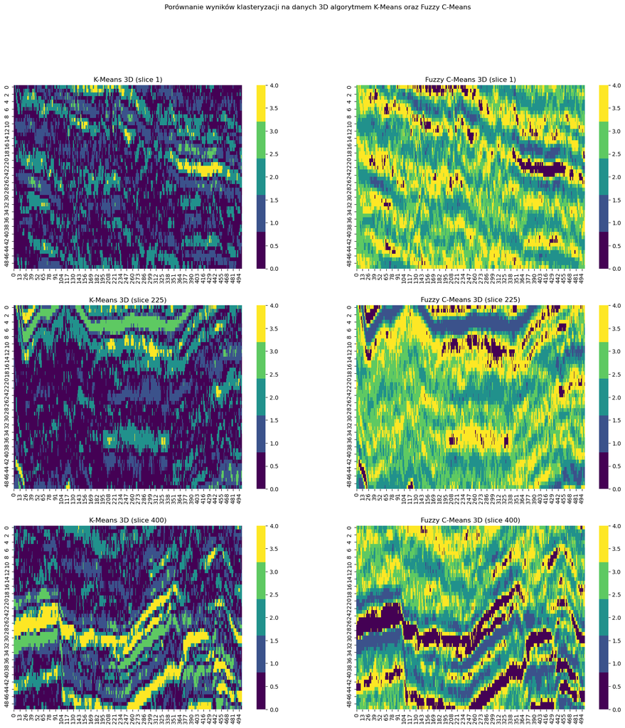

```python
fig, axes = plt.subplots(3, 2, figsize=(20, 20))

sns.heatmap(clustered_cube[1, :, :].T, ax=axes[0, 0], cmap=pal)
sns.heatmap(clustered_cube_fuzzy[1, :, :].T, ax=axes[0, 1], cmap=pal)

sns.heatmap(clustered_cube[225, :, :].T, ax=axes[1, 0], cmap=pal)
sns.heatmap(clustered_cube_fuzzy[225, :, :].T, ax=axes[1, 1], cmap=pal)

sns.heatmap(clustered_cube[400, :, :].T, ax=axes[2, 0], cmap=pal)
sns.heatmap(clustered_cube_fuzzy[400, :, :].T, ax=axes[2, 1], cmap=pal)

axes[0, 0].set(title="K-Means 3D (slice 1)")
axes[0, 1].set(title="Fuzzy C-Means 3D (slice 1)")

axes[1, 0].set(title="K-Means 3D (slice 225)")
axes[1, 1].set(title="Fuzzy C-Means 3D (slice 225)")

axes[2, 0].set(title="K-Means 3D (slice 400)")
axes[2, 1].set(title="Fuzzy C-Means 3D (slice 400)")

fig.suptitle(
    "Porównanie wyników klasteryzacji na danych 3D algorytmem K-Means oraz Fuzzy C-Means"
)
plt.show()
```

Jedną z trywialnych zalet klasteryzacji 3D jest fakt, że na poszczególnych slice'ach poszczególne klasy będą oznaczone tym samym kodem, co umożliwia szybką analizę wielu wycinków naraz (nie jest potrzebna dokładniejsza analiza, która klasa łączy się z którą). W przeciwieńśtwie do klasteryzacji na slice'ach, w tym przypadku widać wyraźniejsze różnice pomiędzy oboma algorytmami. Fuzzy C-Means jest wyraźnie "gładsze" i daje (czysto empiryczne) poczucie większej pewności przy dopasowaniu do klas.

### 3.3 Porównanie klasteryzacji 2D i 3D

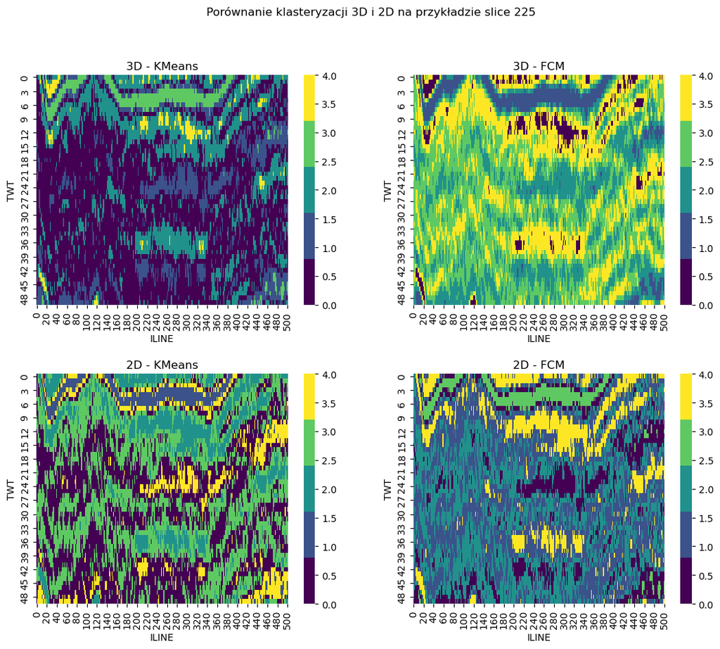

```python
fig, axes = plt.subplots(2, 2, figsize=(13, 10))

sns.heatmap(clustered_cube[225, :, :].T, ax=axes[0, 0], cmap=pal)
sns.heatmap(clustered_cube_fuzzy[225, :, :].T, ax=axes[0, 1], cmap=pal)

sns.heatmap(clustered_slice_225.T, ax=axes[1, 0], cmap=pal)
sns.heatmap(clustered_slice_fuzzy_225.T, ax=axes[1, 1], cmap=pal)

axes[0, 0].set(title="3D - KMeans", xlabel="ILINE", ylabel="TWT")
axes[0, 1].set(title="3D - FCM", xlabel="ILINE", ylabel="TWT")

axes[1, 0].set(title="2D - KMeans", xlabel="ILINE", ylabel="TWT")
axes[1, 1].set(title="2D - FCM", xlabel="ILINE", ylabel="TWT")

fig.suptitle("Porównanie klasteryzacji 3D i 2D na przykładzie slice 225")

plt.subplots_adjust(hspace=0.3)
plt.show()
```

Na powyższej figurze można zobaczyć porównanie klasteryzacji na całym cube 3D (pierwszy rząd) oraz na osobnym slice 2D metodami K-Means oraz Fuzzy C-Means na przykładzie slice'u nr 225. Różnice nie są duże, jednak można zauważyć że:

- Klasteryzacja metodą FCM daje wyniki mniej poszarpane, klastry są bardziej spójne i mniej mieszjaą się między sobą
- Klasteryzacja na danych 3D daje wyniki jeszcze spójniejsze, możliwe że zbyt stałe (niektóre wzorce mogą zostać pominięte)

## 5. Dobór odpowiedniej liczby klastrów

W [artykule]!(https://www.mdpi.com/1996-1073/16/1/493), w rozdziale 3.5 przedstawiono 3 różne metody doboru optymalnej ilości klastrów: Silhouette, Davies-Bouldin Index oraz Calinski-Harabasz Index. Jak wspomniano w tym artykule, dobór liczby klastrów nie jest zadaniem trywialnym i nie ma swojej jednoznacznej odpowiedzi. Jedną z najprostszych metod determinacji liczby klastrów jest metoda "Elbow", która nie została wymieniona w tym artykule. Jest to metoda subiektywna i nie zawsze daje jednoznaczne wyniki, dlatego nie jest ona zbyt popularna, jest jednak metodą najłatwiejszą i najszybszą w użytku. Poniżej sprawdzono ile klastrów należy użyć przy użyciu metody Elbow.

### 5.1 Metoda Elbow

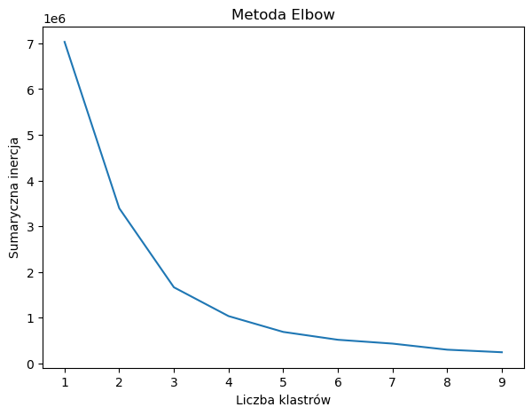

```python
res = []

for i in range(1, 10):
    kmeans = KMeans(n_clusters=i, random_state=44, n_init="auto").fit(
        slice_225_reshaped
    )
    res.append(kmeans.inertia_)


fig, ax = plt.subplots(1, 1, figsize=(7,  5))
sns.lineplot(x=list(range(1, 10)), y=res, ax=ax)
ax.set(title="Metoda Elbow", xlabel="Liczba klastrów", ylabel="Sumaryczna inercja")

plt.show()
```

Jak widać metoda Elbow nie daje jednoznacznej liczby klastrów która powinna być użyta. Kandydaci to 3 i 4. Użycie innych metryk mogłoby dać większa pewność co do liczby klastrów która powinna być użyta, ale wychodzi to poza scope tego projektu.